# NRES 776 Lab 9 - GLM with single predictor

Sunny Tseng

2023-11-15

## Load required libraries

```r
library(tidyverse)
library(here)
library(lmtest)
```

## 1. Poisson regression - horseshoe crab - categorical

This problem refers to data from a study of nesting horseshoe crabs (J. Brockmann, Ethology 1996); see also Agresti (1996) Sec. 4.3 and Agresti (2002) Sec. 4.3. Each female horseshoe crab in the study had a male crab attached to her in her nest. The study investigated factors that affect whether the female crab had any other males, called satellites, residing near her. Explanatory variables that are thought to affect this included the female crab’s color (C), spine condition (S), weight (Wt), and carapace width (W). The response outcome for each female crab is her number of satellites (Sa). There are 173 females in this study.

In this practice, we are going to explore the relationship between number of satellites (Sa) vs color (C) using Poisson regression.

```r
data_crab <- read_table(here("crab_dataset.txt"))

data_crab_clean <- data_crab %>%
  mutate(C = factor(C, labels = c("Light", "Median", "Dark", "Very dark")))
```

```r
data_crab_clean
```

```
## # A tibble: 173 × 6
##       ID C             S    Wt     W    Sa
##    <dbl> <fct>     <dbl> <dbl> <dbl> <dbl>
##  1     1 Median        3  28.3  3.05     8
##  2     2 Dark          3  26    2.6      4
##  3     3 Dark          3  25.6  2.15     0
##  4     4 Very dark     2  21    1.85     0
##  5     5 Median        3  29    3        1
##  6     6 Light         2  25    2.3      3
##  7     7 Very dark     3  26.2  1.3      0
##  8     8 Median        3  24.9  2.1      0
##  9     9 Median        1  25.7  2        8
## 10    10 Median        3  27.5  3.15     6
## # ℹ 163 more rows
```

## Exploratory visualization - Sa vs C

Seems like the number of number of satellites (Sa) decreases as the color (C) gets darker. Interesting observation! We can use statistics to validate this observation.

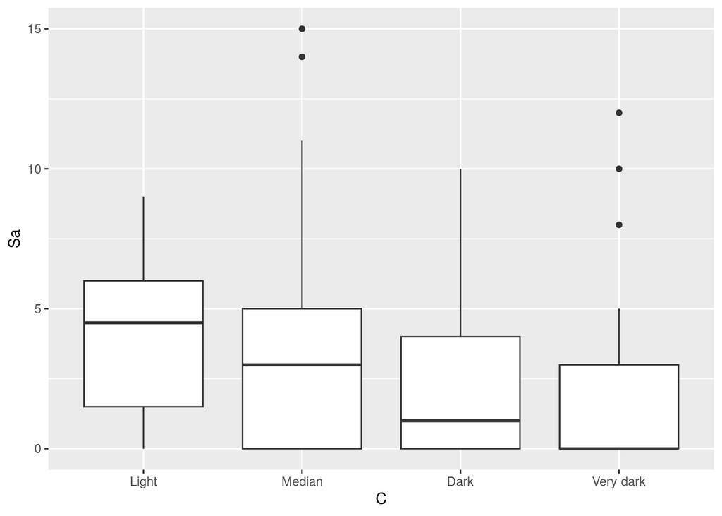

```r
ggplot(aes(x = C, y = Sa), data = data_crab_clean) +
  geom_boxplot()
```

## Fit a Poisson regression

This is the model equation that we are going to fit. Explain why there are three parameters **(2 pt)**

$$log(\mu_i) = \beta_0 + \beta_1 x_{1i} + \beta_2 x_{2i} + \beta_3 x_{3i}$$

*The variable C (colour) has 4 different levels (Lite, Median, Dark, and Very Dark). By using dummy coding, we will need n-1 variables to represent n levels. Thus, we have 3 dummy variables to represent 4 levels.*

Fit a Poisson using `glm()` function. Specify the arguments: `formula`, `data`, and `family`. We will use the default link function, which is a log link. **(3 pt)**

```r
glm_pois_1 <- glm(formula = Sa ~ C,
                  data = data_crab_clean,
                  family = "poisson")
```

Then, use the `summary()` function to print the model output. **(2 pt)**

```r
glm_pois_1 %>% summary()
```

```
##
## Call:
## glm(formula = Sa ~ C, family = "poisson", data = data_crab_clean)
##
## Coefficients:
##             Estimate Std. Error z value Pr(>|z|)
## (Intercept)   1.4069     0.1429   9.848  < 2e-16 ***
## CMedian      -0.2146     0.1536  -1.397 0.162487
## CDark        -0.6061     0.1750  -3.464 0.000532 ***
## CVery dark   -0.6913     0.2065  -3.348 0.000814 ***
## ---
## Signif. codes:  0 '***' 0.001 '**' 0.01 '*' 0.05 '.' 0.1 ' ' 1
##
## (Dispersion parameter for poisson family taken to be 1)
##
##     Null deviance: 632.79  on 172  degrees of freedom
## Residual deviance: 609.14  on 169  degrees of freedom
## AIC: 972.44
##
## Number of Fisher Scoring iterations: 6
```

The model output indicated the estimated values for the parameters, and model statistics. Report these values. (Hint: use `exp()` function and `coef()` function to get exponential value easier) **(3 pt)**

| parameter/statistics | estimated value | exponential of estimated value |
| --- | --- | --- |
| $\beta_0$ | *1.40* | *4.08* |
| $\beta_1$ | *-0.21* | *0.81* |
| $\beta_2$ | *-0.61* | *0.54* |
| $\beta_3$ | *-0.69* | *0.50* |
| dispersion parameter | *1* | NA |
| AIC | *972.44* | NA |

## Model goodness of fit

Is the model including colour as predictor variable better than a null model? If the model performs significantly better than a null model, then we keep the predictor variable; if not, then we say that the colour is not significantly associated with the number of satellite.

Hypothesis of the likelihood ratio test (in words) **(1 pt)**

$H_0$: *The model with colour as predictor has the same performance as the null model*

$H_a$*: The model with colour as predictor has different performance compared to null model*

First, we need to fit a null model **(1 pt)**

```r
glm_pois_null <- glm(formula = Sa ~ 1,
                     data = data_crab_clean,
                     family = "poisson")
```

Then, run a likelihood ratio test **(1 pt)**

```r
lrtest(glm_pois_null, glm_pois_1)
```

```
## Likelihood ratio test
##
## Model 1: Sa ~ 1
## Model 2: Sa ~ C
##   #Df  LogLik Df  Chisq Pr(>Chisq)
## 1   1 -494.04
## 2   4 -482.22  3 23.653  2.952e-05 ***
## ---
## Signif. codes:  0 '***' 0.001 '**' 0.01 '*' 0.05 '.' 0.1 ' ' 1
```

What is your decision based on this likelihood ratio test? (Hint: provide the p-value, the $\alpha$ threshold you are comparing with, and your conclusion) **(3 pt)**

*The p-value of the likelihood ratio test is* $2.9 * 10 ^{-5}$*, which is smaller than the* $\alpha$ *value (0.05). Thus, we reject the null hypothesis. The model with colour as predictor has a better performance compared to the null model. The colour variable contribute significantly in this model.*

## Model result interpretation

Calculate the predicted mean number of satellites for horsecrab with Light colour. Show the calculation process. **(3 pt)**

*Here are the equations for calculating the predicted mean number of satellites for different colours of horsecrab:*

*General equation:* $log(\mu_i) = \beta_0 + \beta_1 x_{1i} + \beta_2 x_{2i} + \beta_3 x_{3i}$

*Light colour:* $log(\mu) = \beta_0$

*Median colour:* $log(\mu) = \beta_0 + \beta_1$

*Dark colour:* $log(\mu) = \beta_0 + \beta_2$

*Very dark colour:* $log(\mu) = \beta_0 + \beta_3$

```r
data_crab_clean %>%
  mutate(predicted = predict(glm_pois_1, type = "response")) %>%
  distinct(C, .keep_all = TRUE)
```

```
## # A tibble: 4 × 7
##      ID C             S    Wt     W    Sa predicted
##   <dbl> <fct>     <dbl> <dbl> <dbl> <dbl>     <dbl>
## 1     1 Median        3  28.3  3.05     8      3.29
## 2     2 Dark          3  26    2.6      4      2.23
## 3     4 Very dark     2  21    1.85     0      2.05
## 4     6 Light         2  25    2.3      3      4.08
```

*Thus, for horsecrab with Light colour, the predicted mean number of satellites is:*

$$\mu = exp(\beta_0) = 4.08$$

Calculate the predicted mean number of satellites for horsecrab with Dark colour. Show the calculation process. **(3 pt)**

*For hoursecrab with Dark colour, the predicted mean number of satellites is:*

$$\mu = exp(\beta_0 + \beta_2) = exp(\beta_0) * exp(\beta_2) = 2.23$$

Is your modelling result showing the same pattern as you observed in the boxplot? Is colour of female horseshoe crab significantly influencing the number of satellite? Explain why or why not, use the model output value as needed. **(3 pt)**

*The colour of female horseshoe crab has significant association with the number of satellite, as tested by the likelihood ratio test. The Poisson regression shows the same pattern as what we observed in the boxplot. That is, the darker the colour, the less the number of satellites a female can get. This is supported by that* estimated $\beta_1$, $\beta_2$, and $\beta_3$ were less than 0.

## 2. Poisson regression - horseshoe crab - continuous

In this practice, we are going to explore the relationship between number of satellites (Sa) vs carapace width (W) using Poisson regression.

## Exploratory visualization - Sa vs W

Seems like the number of satellites (Sa) increases as the carapace width (W) increases. We can use statistics to validate this observation and quantify the effect.

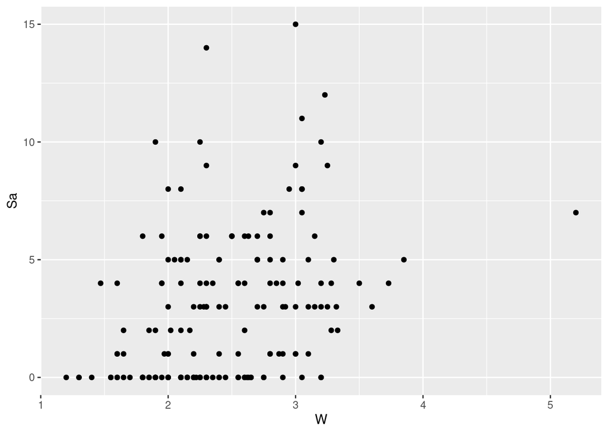

```r
ggplot(aes(x = W, y = Sa), data = data_crab_clean) +
  geom_point()
```

## Fit a Poisson regression

Write out the equation that we are going to fit using Poisson regression. Explain why we only have one predictor variable here. Is the following equation correct? If not, fix it. **(2 pt)**

$$log(\mu_i) = \beta_0 + \beta_1
x_{1i}$$

*The equation is correct. We only have one predictor variable since the predictor now is a continuous variable.*

Fit a Poisson using `glm()` function. Specify the arguments: `formula`, `data`, and `family`. We will use the default link function, which is a log link. **(3 pt)**

```r
glm_pois_2 <- glm(formula = Sa ~ W,
                  data = data_crab_clean,
                  family = "poisson")
```

Then, use the `summary()` function to print the model output. **(2 pt)**

```r
glm_pois_2 %>% summary()
```

```
##
## Call:
## glm(formula = Sa ~ W, family = "poisson", data = data_crab_clean)
##
## Coefficients:
##             Estimate Std. Error z value Pr(>|z|)
## (Intercept)  -0.4282     0.1789  -2.394   0.0167 *
## W             0.5892     0.0650   9.065   <2e-16 ***
## ---
## Signif. codes:  0 '***' 0.001 '**' 0.01 '*' 0.05 '.' 0.1 ' ' 1
##
## (Dispersion parameter for poisson family taken to be 1)
##
##     Null deviance: 632.79  on 172  degrees of freedom
## Residual deviance: 560.84  on 171  degrees of freedom
## AIC: 920.14
##
## Number of Fisher Scoring iterations: 5
```

The model output indicated the estimated values for the parameters, and model statistics. Report these values. (Hint: use `exp()` function and `coef()` function to get exponential value easier) **(3 pt)**

| parameter/statistics | estimated value | exponential of estimated value |
| --- | --- | --- |
| $\beta_0$ | *-0.42* | *0.65* |
| $\beta_1$ | 0.59 | *1.80* |
| dispersion parameter | *1* | NA |
| AIC | *920.14* | NA |

## Model goodness of fit

Is the model including carapace width (W) as predictor variable better than a null model? Use a likelihood ratio test to test it. Write out the hypotheses of the likelihood ratio test (in words) **(1 pt)**

$H_0$: *The model with carapace width as predictor has the same model performance as the null model*

$H_a$: *The model with carapace width as predictor has different model performance compared to the null model*

First, we need to fit a null model **(1 pt)**

```r
glm_pois_null <- glm(formula = Sa ~ 1,
                     data = data_crab_clean,
                     family = "poisson")
```

Then, run a likelihood ratio test **(1 pt)**

```r
lrtest(glm_pois_null, glm_pois_2)
```

```
## Likelihood ratio test
##
## Model 1: Sa ~ 1
## Model 2: Sa ~ W
##   #Df  LogLik Df  Chisq Pr(>Chisq)
## 1   1 -494.04
## 2   2 -458.07  1 71.949  < 2.2e-16 ***
## ---
## Signif. codes:  0 '***' 0.001 '**' 0.01 '*' 0.05 '.' 0.1 ' ' 1
```

What is your decision based on this likelihood ratio test? (Hint: provide the p-value, the $\alpha$ threshold you are comparing with, and your conclusion) **(1 pt)**

*The p-value of teh likelihood ratio test is* $2.2 * 10^{-16}$*, which is smaller than the* $\alpha$ *value (0.05). Thus, we reject the null hypothesis. The model with carapace width as predictor has different model performance compared to the null model. The carapace variable contribute significantly in this model.*

## Model result interpretation

Calculate the predicted mean number of satellites for horsecrab when `W = a`.Show the calculation process. (Hint: your answer should include $a$) **(2 pt)**

*General equation:* $log(\mu_i) = \beta_0 + \beta_1 x_{1i} = \beta_0 + \beta_1W_i$

*Put* $W = a$ *in the equation:*

$$log(\mu_a) = \beta_0 + \beta_1*a$$

$$\mu_a = exp(\beta_0 + \beta_1*a) = exp(\beta_0) * exp(\beta_1 * a)$$

Calculate the predicted mean number of satellites for horsecrab when `W = a + 1`. Show the calculation process. (Hint: your answer should include $a$) **(3 pt)**

*Put* $W = a + 1$ *in the equation:*

$$log(\mu_{a+1}) = \beta_0 +
\beta_1*(a+1)$$

$$\mu_{a+1} = exp(\beta_0 +
\beta_1*(a+1))$$

$$= exp(\beta_0 + \beta_1*a + \beta_1)$$

$$= exp(\beta_0) * exp(\beta_1 *a) * exp(\beta_1)$$

Compare the number of satellites when `W = a` and `W = a + 1` (i.e., calculate $\frac{Sa(W = a+1)}{Sa(W = a)}$). Base one this result, how can you interpret $\beta_1$? (Hint: “one unit increase in $x$ is associated in …”) **(3 pt)**

$$\frac{Sa_{W = a + 1}}{Sa_{W = a}} = \frac{\mu_{a + 1}}{\mu_{a}} =
\frac{exp(\beta_0) * exp(\beta_1 *a) * exp(\beta_1)}{exp(\beta_0) *
exp(\beta_1 * a)}$$

$$= exp(\beta_1)$$

$$= 1.80$$

*Based on this calculation, we can conclude that: with one unit increase in the carapace width, the females are expected to have 1.8 times more number of satellites.*

Is your modelling result showing the same pattern as you observed in the scatter plot? Is carapace width (W) of horseshoe crab significantly influencing the number of satellite? Explain why or why not, use the model output value, or your calculation above, as needed. **(3 pt)**

*The carapace width has significant association with the number of satellites, as tested by the likelihood ratio test. The Poisson regression shows the same pattern as what we observed in the scatter plot. That is, the wider the carapace is, the more satellites that a female has. This is supported by the estimated* $\beta_1$ larger than 0.

## 3. Binomial regression - titanic

The Titanic data set contains information about 887 of the 2229 souls aboard the ill-fated ocean liner Titanic. Each passenger’s record contains the following attributes:

- Name
- Passenger class (1/2/3)
- Sex
- Age
- Whether the passenger was accompanied by siblings, parents or children
- The Fare they paid, and most importantly,
- **Whether they survived (1=Survived, 0=Died)**

In this practice, we want to know whether the survival probability (`Survival`) is influence by the passenger class (`Pclass`).

## Load required libraries and data set

```r
data_titanic <- read_csv(here("titanic_dataset.csv"))

data_titanic_clean <- data_titanic %>%
  mutate(Pclass = factor(Pclass, labels = c("First", "Second", "Third")))
```

```r
data_titanic_clean
```

```
## # A tibble: 887 × 8
##    Name   Pclass Sex     Age Siblings/Spouses Abo…¹ Parents/Children Abo…²  Fare
##    <chr>  <fct>  <chr> <dbl>                  <dbl>                  <dbl> <dbl>
##  1 Mr. O… Third  male     22                      1                      0  7.25
##  2 Mrs. … First  fema…    38                      1                      0 71.3
##  3 Miss.… Third  fema…    26                      0                      0  7.92
##  4 Mrs. … First  fema…    35                      1                      0 53.1
##  5 Mr. W… Third  male     35                      0                      0  8.05
##  6 Mr. J… Third  male     27                      0                      0  8.46
##  7 Mr. T… First  male     54                      0                      0 51.9
##  8 Maste… Third  male      2                      3                      1 21.1
##  9 Mrs. … Third  fema…    27                      0                      2 11.1
## 10 Mrs. … Second fema…    14                      1                      0 30.1
## # ℹ 877 more rows
## # ℹ abbreviated names: ¹`Siblings/Spouses Aboard`, ²`Parents/Children Aboard`
## # ℹ 1 more variable: Survived <dbl>
```

## Exploratory visualization - Survival vs Pclass

Seems like the survival rate is lower in Third class comparing to First class. We can use statistics to validate this observation.

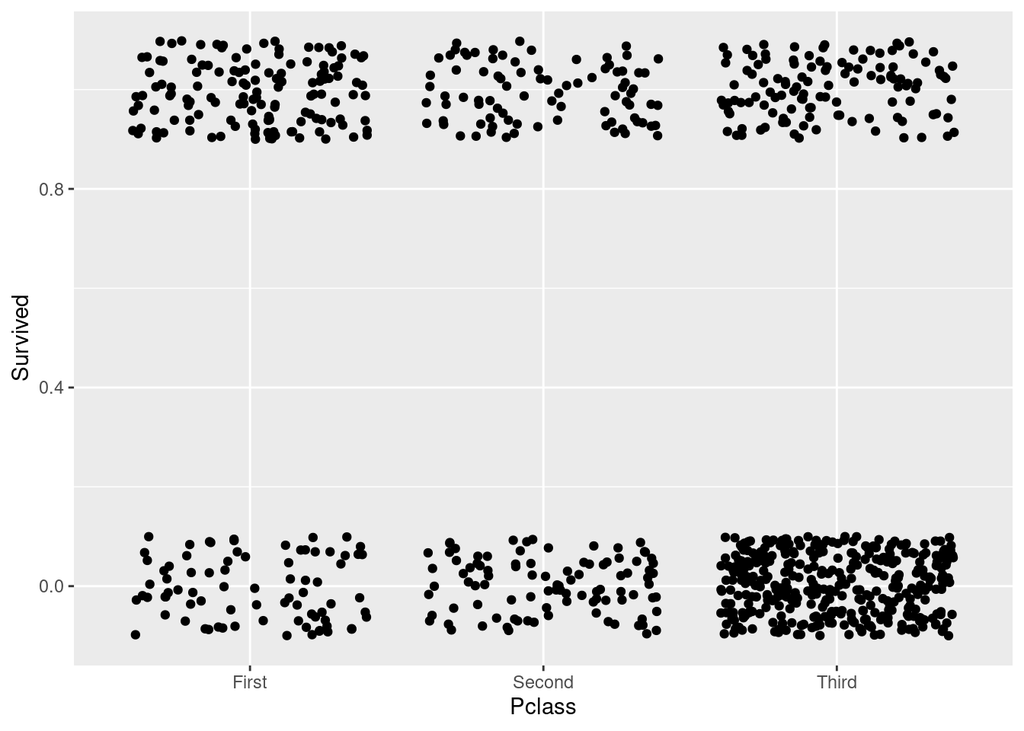

```r
ggplot(aes(x = Pclass, y = Survived),
       data = data_titanic_clean) +
  geom_jitter(height = 0.1)
```

## Fit a Binomial regression

Write out the model equation. Explain why there are two predictor variables in the equation. **(2 pt)**

$$logit(p_i) = \beta_0 + \beta_1 x_{1i} +
\beta_2 x_{2i}$$

*Because the passenger class is a categorical variable, with 3 levels (First, Second, and Third). In dummy coding, we need two dummy variables to represent 3 levels in a categorical variable.*

Fit a Binomial regression using `glm()` function. Specify the arguments: `formula`, `data`, and `family`. We will use the default link function, which is a logit link. **(3 pt)**

```r
glm_binom_1 <- glm(formula = Survived ~ Pclass,
                   data = data_titanic_clean,
                   family = "binomial")
```

Then, use the `summary()` function to print the model output. **(2 pt)**

```r
glm_binom_1 %>% summary()
```

```
##
## Call:
## glm(formula = Survived ~ Pclass, family = "binomial", data = data_titanic_clean)
##
## Coefficients:
##              Estimate Std. Error z value Pr(>|z|)
## (Intercept)    0.5306     0.1409   3.766 0.000166 ***
## PclassSecond  -0.6394     0.2041  -3.133 0.001731 **
## PclassThird   -1.6596     0.1760  -9.430  < 2e-16 ***
## ---
## Signif. codes:  0 '***' 0.001 '**' 0.01 '*' 0.05 '.' 0.1 ' ' 1
##
## (Dispersion parameter for binomial family taken to be 1)
##
##     Null deviance: 1182.8  on 886  degrees of freedom
## Residual deviance: 1080.9  on 884  degrees of freedom
## AIC: 1086.9
##
## Number of Fisher Scoring iterations: 4
```

The model output indicated the estimated values for the parameters, and model statistics. Report these values. (Hint: use `exp()` function and `coef()` function to get exponential value easier) **(3 pt)**

| parameter/statistics | estimated value | exponential of estimated value |
| --- | --- | --- |
| $\beta_0$ | 0.53 | *1.7* |
| $\beta_1$ | *-0.63* | *0.52* |
| $\beta_2$ | *-1.65* | *0.19* |
| dispersion parameter | *1* | NA |
| AIC | *1086.9* | NA |

## Model goodness of fit

Is the model including passenger class as predictor variable better than a null model? If the model performs significantly better than a null model, then we keep the predictor variable; if not, then we say that the passenger class is not significantly associated with the survival rate.

Hypothesis of the likelihood ratio test (in words) **(1 pt)**

$H_0$: *The model including passenger class as predictor performs the same as the null model*

$H_a$: *The model including passenger class as predictor performs differently compared to the null model*

First, we need to fit a null model **(1 pt)**

```r
glm_binom_null <- glm(formula = Survived ~ 1,
                      data = data_titanic_clean,
                      family = "binomial")
```

Then, run a likelihood ratio test **(1 pt)**

```r
lrtest(glm_binom_null, glm_binom_1)
```

```
## Likelihood ratio test
##
## Model 1: Survived ~ 1
## Model 2: Survived ~ Pclass
##   #Df  LogLik Df  Chisq Pr(>Chisq)
## 1   1 -591.38
## 2   3 -540.44  2 101.89  < 2.2e-16 ***
## ---
## Signif. codes:  0 '***' 0.001 '**' 0.01 '*' 0.05 '.' 0.1 ' ' 1
```

What is your decision based on this likelihood ratio test? (Hint: provide the p-value, the $\alpha$ threshold you are comparing with, and your conclusion) **(3 pt)**

*The p-value of the likelihood ratio test is* $2.2 * 10 ^ {-16}$*, which is smaller than the* $\alpha$ *level (0.05). Thus, we reject the null hypothesis. The model including passenger class as predictor has significant different model performance compared to null model. The passenger class is significantly associated with the survival rate.*

## Model result interpretation

Calculate the odds of a passenger being survived if they are sitting in first class. Show the calculation process. **(3 pt)**

General equation: $logit(p_i) = \beta_0 + \beta_1 x_{1i} + \beta_2 x_{2i}$

First class: $logit(p_i) = \beta_0$

Second class: $logit(p_i) = \beta_0 + \beta_1$

Third class: $logit(p_i) = \beta_0 + \beta_2$

```r
data_titanic_clean %>%
  mutate(predicted = predict(glm_binom_1, type = "response")) %>%
  summarize(prob_survival = mean(predicted),
            .by = Pclass) %>%
  mutate(odds_survival = prob_survival/(1-prob_survival))
```

```
## # A tibble: 3 × 3
##   Pclass prob_survival odds_survival
##   <fct>          <dbl>         <dbl>
## 1 Third          0.244         0.323
## 2 First          0.630         1.70
## 3 Second         0.473         0.897
```

*The odds of the survival for the first class passenger:*

$$Odds_{first} = exp(\beta_0) = 1.7$$

Calculate the survival odds ratio of sitting in third class comparing to sitting in the first class. Show the calculation process. **(3 pt)**

*The odds of survival for the third class passenger:*

$$Odds_{third} = exp(\beta_0 + \beta_2)$$

$$= exp(\beta_0) * \exp(\beta_2) = 0.323$$

*Compare the Odds ratio between third and the first class:*

$$\frac{Odds_{third}}{Odds_{first}} = \frac{exp(\beta_0) *
\exp(\beta_2)}{exp(\beta_0)}$$

$$= exp(\beta_2) = 0.19$$

*Passengers sitting in the third class has 0.19 times less odds of survival compared to the passengers sitting in the first class.*

Is your modelling result showing the same pattern as you observed in the scatter plot? Is passenger class a significant variable to explain survival rate? Explain why or why not, use the model output value as needed. **(3 pt)**

*The passenger is a significant variable in the model based on the likelihood ratio test. And yes, the model result supports the observation as both the coefficient* $\beta_1$ *and* $\beta_2$ *are less than zero, which means the second class and third class has lower odds in survival comparing to the first class passengers.*

## 4. Binomial regression - titanic

In this practice, we want to know whether the survival probability (`Survival`) is influence by the fare they paid (`Fare`).

## Exploratory visualization - Survival vs Fare

Seems like the survival rate has positive relationship with the fare. We can use statistics to validate this observation.

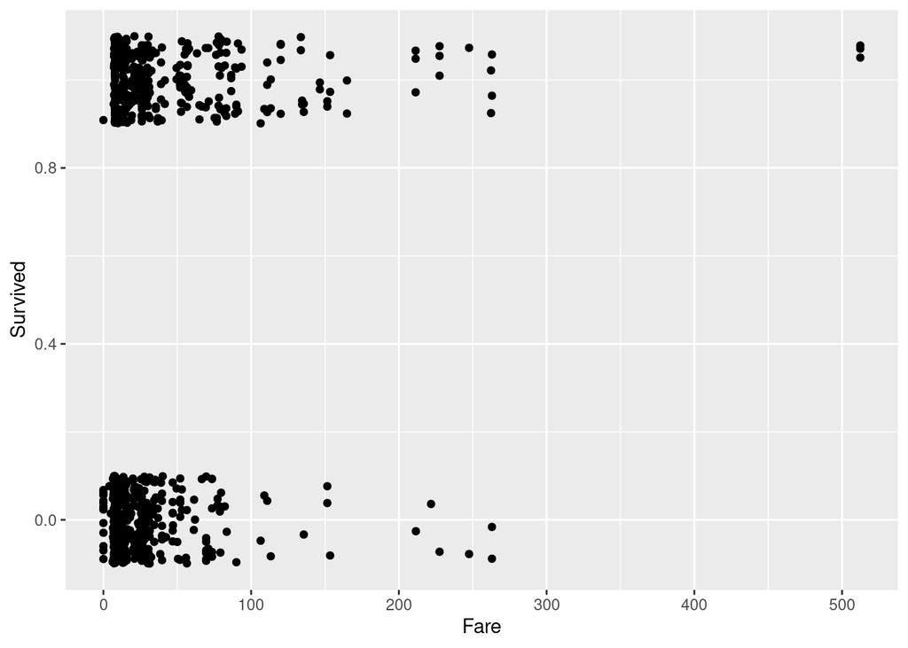

```r
ggplot(aes(x = Fare, y = Survived),
       data = data_titanic_clean) +
  geom_jitter(height = 0.1)
```

## Fit a Binomial regression

Write out the model equation. Explain why there are two predictor variables in the equation. Explain why there is only one predictor variable in the equation. **(2 pt)**

$$logit(p_i) = \beta_0 + \beta_1
x_{1i}$$

*Because we only have 1 continuous variable in the model here.*

Fit a Binomial regression using `glm()` function. Specify the arguments: `formula`, `data`, and `family`. We will use the default link function, which is a logit link. **(3 pt)**

```r
glm_binom_2 <- glm(formula = Survived ~ Fare,
                   data = data_titanic_clean,
                   family = "binomial")
```

Then, use the `summary()` function to print the model output. **(2 pt)**

```r
summary(glm_binom_2)
```

```
##
## Call:
## glm(formula = Survived ~ Fare, family = "binomial", data = data_titanic_clean)
##
## Coefficients:
##              Estimate Std. Error z value Pr(>|z|)
## (Intercept) -0.931730   0.095215  -9.786  < 2e-16 ***
## Fare         0.015084   0.002228   6.771 1.28e-11 ***
## ---
## Signif. codes:  0 '***' 0.001 '**' 0.01 '*' 0.05 '.' 0.1 ' ' 1
##
## (Dispersion parameter for binomial family taken to be 1)
##
##     Null deviance: 1182.8  on 886  degrees of freedom
## Residual deviance: 1114.6  on 885  degrees of freedom
## AIC: 1118.6
##
## Number of Fisher Scoring iterations: 4
```

The model output indicated the estimated values for the parameters, and model statistics. Report these values. (Hint: use `exp()` function and `coef()` function to get exponential value easier) **(3 pt)**

| parameter/statistics | estimated value | exponential of estimated value |
| --- | --- | --- |
| $\beta_0$ | *-0.93* | *0.39* |
| $\beta_1$ | *0.01* | *1.015* |
| dispersion parameter | *1* | NA |
| AIC | *1118.6* | NA |

## Model goodness of fit

Is the model including fare as predictor variable better than a null model? We use likelihood ratio test to answer this question. Hypothesis of the likelihood ratio test (in words) **(1 pt)**

$H_0$: *The model with Fare as predictor performs the same as the null model*

$H_a$: *The model with Fare as predictor has different model performance compared to the null model*

First, we need to fit a null model **(1 pt)**

```r
glm_binom_null <- glm(Survived ~ 1,
                      data = data_titanic_clean,
                      family = "binomial")
```

Then, run a likelihood ratio test **(1 pt)**

```r
lrtest(glm_binom_null, glm_binom_1)
```

[output not shown]

## Model result interpretation

Calculate the odds of a passenger being survived if they are paying $a$ (`Fare = a`). Show the calculation process. **(2 pt)**

*General equation:* $logit(p_i) = \beta_0 + \beta_1 x_{1i}$

*Put* $Fare = a$ *in the equation:*

$$logit(p_a) = \beta_0 + \beta_1*a$$

$$Odds_a = exp(\beta_0 + \beta_1 * a) = exp(\beta_0) * exp(\beta_1 * a)$$

Calculate the odds of a passenger being survived if they are paying $a + 1$ (`Fare = a + 1`). Show the calculation process. **(3 pt)**

*Put* $Fare = a + 1$ *in the equation:*

$$logit(p_{a+1}) = \beta_0 +
\beta_1*(a+1)$$

$$Odds_{a+1} = exp(\beta_0 + \beta_1 *
(a+1))$$

$$= exp(\beta_0 + \beta_1 * a + \beta_1)$$

$$= exp(\beta_0) * exp(\beta_1 * a) * exp(\beta_1)$$

Compare the odds `Fare = a` and `Fare = a + 1` (i.e., calculate the odds ratio). Base one this result, how can you interpret $\beta_1$? (Hint: “one unit increase in $x$ is associated in …”) **(3 pt)**

$$\frac{Odds_{a+1}}{Odds_a} = \frac{exp(\beta_0) * exp(\beta_1 * a) *
exp(\beta_1)}{exp(\beta_0) * exp(\beta_1 * a)}$$

$$= exp(\beta_1)$$

$$= 1.015$$

*One unit increase in Fare is associated with 1.015 times increase in the odds of survival. If you pay* $100$ *dollors more, you will have* $1.015^{100}$ *times, which is about 4 times, more odds of survival compared to the person who pays* $100$ *dollars less than you.*

Is your modelling result showing the same pattern as you observed in the scatter plot? Is fare a significant variable to explain survival rate? Explain why or why not, use the model output value as needed. **(3 pt)**

*Yes, the model result supported our observation in the scatter plot. That is, the Fare has positive relationship with the survival rate. This is supported by the fact that the estimated* $\beta_1$ *is a positive value.*